# Monthly pension returns analysis: Velliv June 2012 - April 2024

## Convergence

### Max vs sum

Max-vs-sum plots for the first four moments – a ratio that doesn’t fall toward zero flags that moment as possibly non-existent (see “Max-sum plots” in the comparison report for what this diagnostic tests). Panels by fitted distribution:

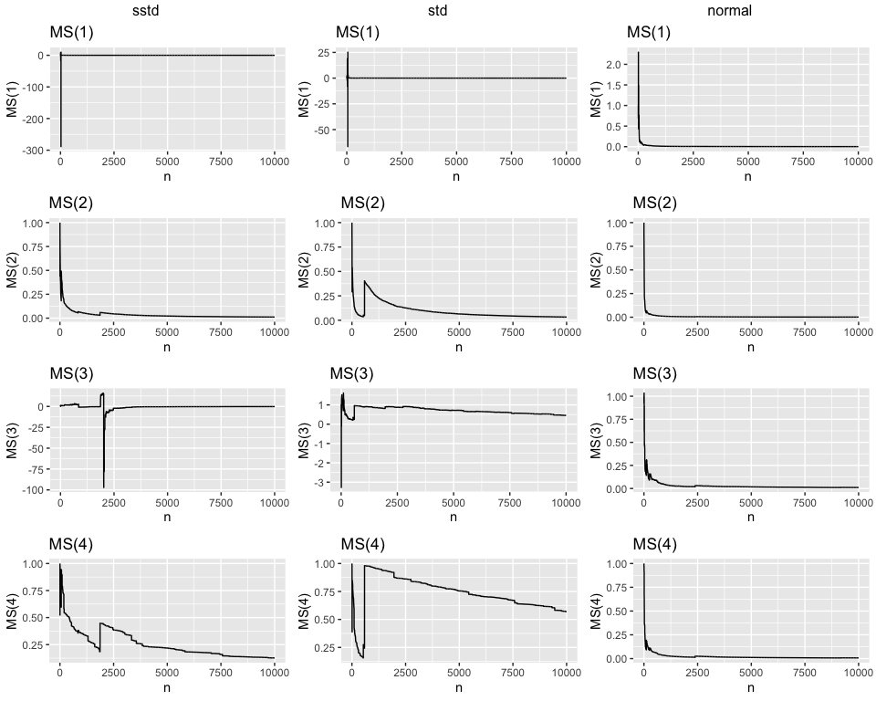

### MC

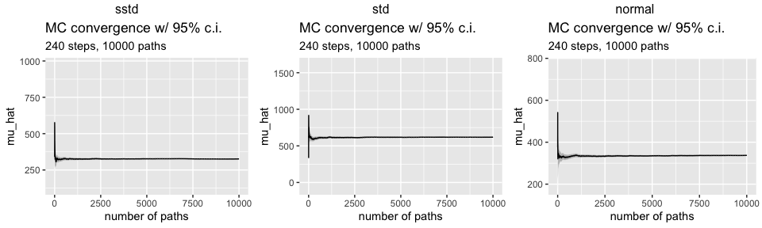

### IS

Skewed $t$-distribution with a normal proposal distribution.

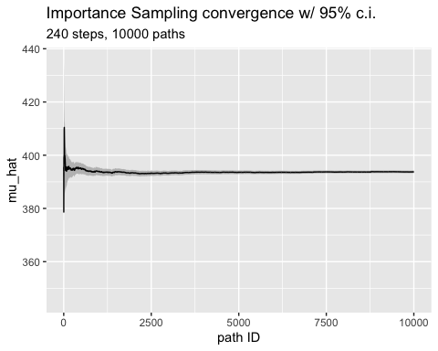

Parameters

```
## [1] 1.4575522 0.4135162
```

Objective function plots

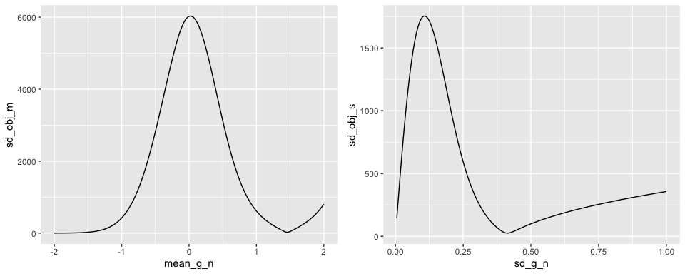

# Findings

With the data deliberately frozen, we can interpret a fixed set of estimates rather than chase a moving target. We present the salient results, analyse them against the theory that motivates the study, and draw out the implications.

## 1. The plans are weighted blends of the same two funds

*Result.* A principal component analysis of the four plans gives a first component that explains 97.7% of the variance and loads almost equally on all four, with the first two components together at 99.4%. Within each provider the high-risk plan is a scalar multiple of the medium-risk plan in log returns, with slope 1.26 for Velliv and 1.60 for PFA, intercept near zero, and $R^2$ of 0.994 and 0.955. Correlations run from 0.95 across providers to 0.997 within Velliv. For PFA the two building blocks recovered from profiles B and D, the high-risk fund as $D$ and the low-risk fund as $2B-D$, are only moderately correlated (0.59) and differ several-fold in volatility (ratio 3.1).

*Analysis.* The single dominant component is an empirical result: The four plans are, to a close approximation, one common factor seen at four exposures, and the within-provider scaling is the special case of this. The further statement that PFA’s profiles are blends of exactly two funds, with the high-risk fund equal to $D$ and the low-risk fund equal to $2B-D$, rests on PFA’s stated profile weights rather than on the data, which only confirm that the recovered low-risk fund is coherent. PFA states that profile B is a 50/50 blend of its high- and low-risk funds and profile D is the high-risk fund alone, so the profiles are fixed affine combinations of the same two funds.

*Implication.* The investor’s first decision within a provider is how much of one factor to hold, not which portfolio.

## 2. “Risk” is leverage on that factor, and within a provider there is nothing to optimise

*Result.* Because the slope exceeds 1 with near-zero intercept, the high-risk plan amplifies the common factor symmetrically: Higher average growth, but deeper drawdowns (worst monthly peak-to-trough 17.3% against 15.2% for Velliv, 15.9% against 11.9% for PFA) and underperformance in flat or falling markets. The much-noted fact that the cumulative high-risk path never dips below the medium-risk path holds only for an index started at the 2012 low. Rebased to the eve of the COVID drawdown, the high plan trails the medium plan for about nine months. The reward-to-risk ratio is near-constant along the menu: The high-plan Sharpe equals the medium-plan Sharpe times their correlation, so Velliv (correlation 0.997) is a near-perfect leverage ray and PFA (0.977) bends by about two percent. That bend, and the medium-to-high Sharpe gap, are well inside one standard error.

*Analysis.* With the high plan a scaled version of the medium plan in log returns, it lies below the medium plan exactly over windows in which the medium plan is below its entry value. Non-crossing is a property of the entry date relative to the cycle, not of the plans. The near-constant Sharpe is the same scaling seen as reward per unit of risk, a leverage ray rather than a curve with a best point to locate.

*Implication.* The risk level is a pure risk-appetite decision. There is no identifiable best-Sharpe blend to chase, in added risk or in fees.

## 3. The body of the distribution is estimable; the tail is not

This is the methodological core. We fit a four-parameter Fernández-Steel skewed Student-t, with location m, scale s, tail index nu, and skew xi. The parameters split sharply by how much data they require.

*The location and scale are estimable.* The mean and scale have small relative standard errors, comparable to what a Gaussian of the same moments would give. For vmr the monthly mean is 0.005 with standard error 0.0022, so the positive drift is real.

*The tail and skew are the hard parameters, and they carry the risk.* The tail index runs 3.3 to 4.0 monthly, with relative standard errors of 34% to 38% and a 95% interval for vmr of roughly [1.1, 5.7]. That interval straddles nu = 2, below which the variance ceases to exist, and nu = 4, below which the kurtosis does. The skew runs 0.70 to 0.77 with an interval lying entirely below 1, about 3.5 standard errors from symmetry. The left skew is statistically established; the tail index is not pinned down. The annual report, with 13 observations, cannot identify nu at all: The information matrix is singular for three of the four plans, and xi is driven to a degenerate corner.

*Analysis, why nu and xi are hard while m is easy.* The Gaussian has only m and s. The t adds nu and xi, which govern the tail and have no Gaussian counterpart, so the entire data burden lives in them. Taleb’s recommended workflow is to estimate the tail exponent by maximum likelihood and then derive the mean analytically by plug-in, because the tail exponent captures the low-probability deviations better than the sample mean does. The catch is that plug-in presupposes an estimable nu, which we have at best loosely monthly and not at all annually. The convergence metric kappa makes the asymmetry precise: For these fits kappa is about 0.14, so matching the convergence of 30 Gaussian observations takes about 55 observations of the fitted t, a threshold the 142 monthly points clear. That metric concerns the mean. The tail parameters are harder still, so an adequately converged mean is a floor, not a guarantee, for the tail.

*Implication.* The direction of the tail, fat and left-skewed, is robust where we have power. Its magnitude is not pinned down even monthly.

## 4. The departure from the Gaussian is real and lies in the tail

*Result.* AIC and BIC both prefer the skewed-t for every fund, but those criteria, like the probability-plot correlation, weigh the body. The tail-weighted Anderson-Darling test, with bootstrap p-values, rejects the normal (p at most 0.002) and the symmetric-t (p 0.002 to 0.010) for every fund, and fails to reject only the skewed-t. The skew, not merely fat tails, is needed. Lilliefors rejects normality outright (p near zero). Under a fitted Gaussian the smallest observed monthly return is effectively impossible, recurring once every 400,000 to 2,000,000 years against once every roughly 180 to 290 years under the skewed-t. We cannot confirm finite variance, since the nu interval includes nu < 2 for every fund, and for nu at or below 2 the sample standard deviation does not converge and E[100 e^X] is undefined.

*Analysis.* The probability-plot correlation, reported as PPCC, is a statement about the body, and a high value does not validate the tail. The max-sum plots ask the prior question of whether the relevant moments exist at all, and read together with the wide nu interval they leave finite variance unconfirmed. The variance-based statistics, and the symmetric-t simulation, therefore rest on an assumption the data cannot secure.

*Implication.* Any Gaussian or variance-based risk number understates the downside that matters.

## 5. The simulated wealth distribution is the core result, and the distribution choice governs it

*Result.* The Monte Carlo simulations of accumulated wealth are the central output, and they hinge on the estimated tail parameters diagnosed above. Simulated over twenty years as a single black-box fit per series, the probability of finishing below the starting value is about 0.30 for the Velliv plans under the skewed-t, against 0.01 to 0.02 under the symmetric-t or the normal. PFA’s plans stay near 0.01 to 0.02 under all three, helped by a higher reward-to-risk ratio. The worst simulated Velliv-medium path falls close to a tenth of its starting value.

*Analysis.* The driver is the established left skew interacting with Velliv’s higher volatility. The symmetric models hide a downside that the better-fitting and statistically established skew reveals. The shape of the wealth distribution is itself worth stating: It is right-skewed and bounded below at zero, even though the log-return distribution that generates it is left-skewed and unbounded. Because wealth is $100\,e^{R}$, exponentiating never produces a negative value, so the heavy left tail in log space becomes a cluster of paths near zero rather than a set of negative balances. The same bound is why the plans behave like log-return scaling rather than constant financial leverage: They are long-only blends whose weights sum to one, so they cannot be wiped out.

*Implication.* We report the skewed-t outcome as the operative one. These results carry over to the investor-facing analysis, where the choice between risk levels and across providers is made.

## 6. A precautionary reading, and the bottom line

*The asymmetry of the inference.* The fits are heavy-left-skewed with a small positive mean, a shape that predicts losses worse than any yet observed, and the benign, low-rate, bull-market sample has not delivered them. One could object that more data might instead reveal large upside, symmetrising the fit and thinning the tail. Two considerations weigh against that hope. Taleb’s escape, to stay home when no reliable estimator exists, is unavailable for a compulsory pension, and his qualifier, that one may still take risky decisions if bounded for maximum losses, does not apply because a pension is not bounded that way. And the sample is a single regime, more likely to understate than overstate the tail.

*A speculative but coherent mechanism.* The observed shape, a left skew with a positive mean, is what a return-capping design would produce. Trimming large gains while leaving the occasional large loss to be booked as chance pushes the mean up. We cannot establish design from the data, but the shape is consistent with it, and prudence argues for taking the heavy left skew at face value until evidence says otherwise.

*The cost of this precaution.* Assuming a heavier left tail also raises the apparent value of diversifying across the two providers, since the tail-softening from holding both is larger the fatter the assumed idiosyncratic tail. Precaution here is therefore not free, and the trade-off is properly weighed in the investor-facing analysis.

*Bottom line.* Qualitatively the conclusions are firm: The plans are leverage on one factor, the tails are fat and left-skewed, drawdowns are asymmetric, and path-dominance is a starting-point artefact. Quantitatively, the mean, the scale, and the direction of the skew are established monthly, but the tail index is not pinned down at 142 observations and is unidentified at 13. Because the simulated wealth distribution turns on that tail, and because “staying home” is not an option, we treat the distribution as heavily left-skewed while flagging that this stance may overstate the benefit of diversifying across providers.

# Appendix

## Infinite variance

Taleb, Statistical Consequences Of Fat Tails, p. 97 “the variance of a finite variance random variable with tail exponent $< 4$ will be infinite”.

And p. 363:  
“The hedging errors for an option portfolio (under a daily revision regime) over 3000 days, under a constant volatility Student T with tail exponent $\alpha = 3$. Technically the errors should not converge in finite time as their distribution has infinite variance.”

## QQ lines

Note: QQ lines by design pass through 1st and 3rd quantiles. They are not trendlines in the sense of linear regression.

## Arithmetic vs geometric mean

Let $m$ be the number of steps in each path and $n$ be the number of paths. $a$ is the initial capital. Use arithmetic mean for mean of all paths at time $t$:
$$\dfrac{a (e^{z_1} + e^{z_2} + \dots + e^{z_n})}{n}$$
where
$$z_i := x_{i, 1} + x_{i, 2} + \dots + x_{i, m}$$
Use geometric mean for mean of all steps in a single path $i$:
$$a e^{\frac{x_{i, 1} + x_{i, 2} + \dots + x_{i, m}}{m}} = a \sqrt[m]{e^{x_{i, 1} + x_{i, 2} + \dots + x_{i, m}}}$$

So for **Monte Carlo** of returns after $m$ periods, we

- fit a skewed t-distribution to log-returns and use that distribution to simulate $\{x_{i, j}\}_j^m$,
- for each path $i$, calculate $100\cdot e^{z_i}$,
- calculate the mean of $\{z_i\}_i^n$:
  - $$\bar{z} = 100\dfrac{e^{z_1} + e^{z_2} + \dots + e^{z_n}}{n}$$

For **Importance Sampling**, we

- model log-returns on a skewed t-distribution,
- for each path $i$, calculate $100\cdot e^{z_i}$,
- fit a skewed t-distribution to $\{z_i\}_i^n$ and use it as our $f$ density function from which we simulate $\{h_i\}_i^n$,
  - In our case $h$ and $z$ are identical, because we have an idea for a distribution to simulate $z$, but in general for IS $h$ could be a function of $z$.
- calculate $w* = \frac{f}{g^*}$, where $g*$ is our proposal distribution, which minimizes the variance of $h\cdot w$.
- calculate the arithmetic mean of $\{h_i w_i^{*}\}_i^n$:
  - $$100 \dfrac{e^{h_1 w_1^{*}} + e^{h_2 w_2^{*}} + \dots + e^{h_n w_n^{*}}}{n}$$

## Average of returns vs returns of average

### Math

$$\text{Avg. of returns} := \dfrac{ \left(\dfrac{x_t}{x_{t-1}} + \dfrac{y_t}{y_{t-1}} \right) }{2}$$
$$\text{Returns of avg.} := \left(\dfrac{ x_t + y_t }{2}\right) \Big/ \left(\dfrac{ x_{t-1} + y_{t-1} }{2}\right) \equiv \dfrac{ x_t + y_t }{ x_{t-1} + y_{t-1}}$$

For which $x_1$ and $y_1$ are $\text{Avg. of returns} = \text{Returns of avg.}$?

$$\dfrac{ \left(\dfrac{x_t}{x_{t-1}} + \dfrac{y_t}{y_{t-1}} \right) }{2} = \dfrac{ x_t + y_t }{ x_{t-1} + y_{t-1}}$$

$$\dfrac{x_t}{x_{t-1}} + \dfrac{y_t}{y_{t-1}} = 2 \dfrac{ x_t + y_t }{ x_{t-1} + y_{t-1}}$$

$$(x_{t-1} + y_{t-1}) x_t y_{t-1} + (x_{t-1} + y_{t-1}) x_{t-1} y_t = 2 (x_{t-1}y_{t-1}x_t + x_{t-1}y_{t-1}y_t)$$

$$(x_{t-1}x_ty_{t-1} + y_{t-1}x_ty_{t-1}) + (x_{t-1}x_{t-1}y_t + x_{t-1}y_{t-1}y_t) = 2(x_{t-1}y_{t-1}x_t + x_{t-1}y_{t-1}y_t)$$
This is not generally true, but true if for instance $x_{t-1} = y_{t-1}$.

### Example

Definition: `R = 1+r`

```
## Let x_0 be 100.
```

```
## Let y_0 be 200.
```

```
## So the initial value of the pf is 300 .
```

```
## Let R_x be 0.5.
```

```
## Let R_y be 1.5.
```

Then,

```
## x_1 is R_x * x_0 = 50.
```

```
## y_1 is R_y * y_0 = 300.
```

Average of returns:

```
## 0.5 * (R_x + R_y) = 1
```

So here the value of the pf at t=1 should be unchanged from t=0:

```
## (x_0 + y_0) * 0.5 * (R_x + R_y) = 300
```

But this is clearly not the case:

```
## 0.5 * (x_1 + y_1) = 0.5 * (R_x * x_0 + R_y * y_0) = 175
```

Therefore we should take returns of average, not average of returns!

Let’s take the average of log returns instead:

```
## 0.5 * (log(R_x) + log(R_y)) = -0.143841
```

We now get:

```
## (x_0 + y_0) * exp(0.5 * (log(Rx) + log(Ry))) = 259.8076
```

So taking the average of log returns doesn’t work either.

## Simulation of mix vs mix of simulations

Test if a simulation of a mix (average) of two returns series has the same distribution as a mix of two simulated returns series.

```
## m(data_x): 0.07743984
## s(data_x): 0.3969865
## m(data_y): 9.371997
## s(data_y): 2.545459
##
## m(data_x + data_y): 4.724718
## s(data_x + data_y): 1.303076
```

m and s of final state of all paths.  
`_a` is mix of simulated returns.  
`_b` is simulated mixed returns.

| m_a | m_b | s_a | s_b |
| --- | --- | --- | --- |
| 94.377 | 94.438 | 5.612 | 5.774 |
| 94.799 | 94.801 | 5.703 | 5.873 |
| 94.208 | 94.689 | 5.876 | 5.804 |
| 94.402 | 94.395 | 5.904 | 5.978 |
| 94.474 | 94.401 | 5.866 | 5.777 |
| 94.456 | 94.442 | 5.792 | 5.897 |
| 94.302 | 94.373 | 5.594 | 5.815 |
| 94.594 | 94.268 | 5.773 | 5.749 |
| 94.087 | 94.258 | 5.823 | 5.970 |
| 94.776 | 94.200 | 5.906 | 5.828 |

```
##       m_a             m_b             s_a             s_b
##  Min.   :94.09   Min.   :94.20   Min.   :5.594   Min.   :5.749
##  1st Qu.:94.32   1st Qu.:94.29   1st Qu.:5.721   1st Qu.:5.784
##  Median :94.43   Median :94.40   Median :5.808   Median :5.822
##  Mean   :94.45   Mean   :94.43   Mean   :5.785   Mean   :5.847
##  3rd Qu.:94.56   3rd Qu.:94.44   3rd Qu.:5.873   3rd Qu.:5.891
##  Max.   :94.80   Max.   :94.80   Max.   :5.906   Max.   :5.978
```

`_a` and `_b` are very close to equal.  
We attribute the differences to differences in estimating the distributions in version a and b.

The final state is independent of the order of the preceding steps:

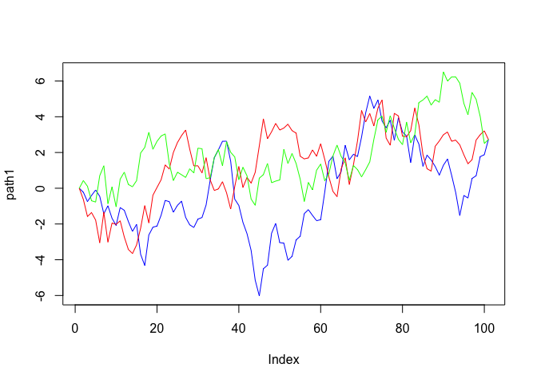

So does the order of the steps in the two processes matter, when mixing simulated returns?

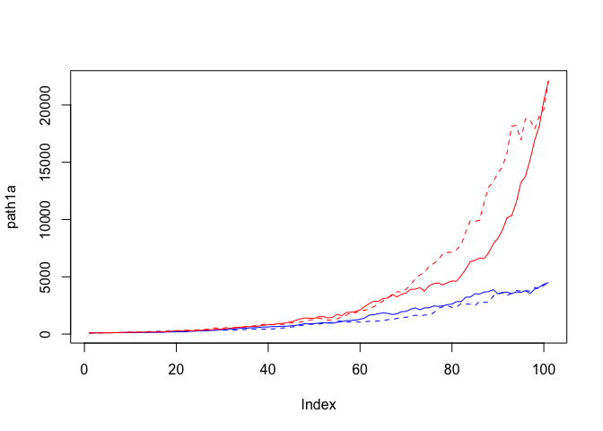

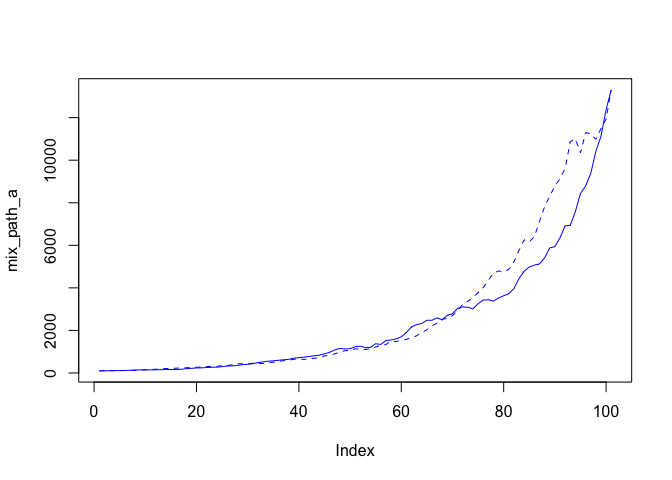

Recall,
$$\text{Var}(aX+bY) = a^2 \text{Var}(X) + b^2 \text{Var}(Y) + 2ab \text{Cov}(a, b)$$

```r
var(0.5 * data_df$vhr + 0.5 * data_df$phr)
```

```
## [1] 0.0008537742
```

```r
0.5^2 * var(data_df$vhr) + 0.5^2 * var(data_df$phr) + 2 * 0.5 * 0.5 * cov(data_df$vhr, data_df$phr)
```

```
## [1] 0.0008537742
```

Our distribution estimate is based on 142 monthly observations. Is that enough for a robust estimate? What if we suddenly hit a month like the 2008 crash? How would that affect our estimate?  
Let’s try to include the Velliv data going back to 2007, which spans the GFC.  
We do this by sampling 142 observations from the long series `vmrl` (`data_df_l$vmrl`, 207 monthly observations incl. 2007-2012).

```
##        m                  s
##  Min.   :0.005381   Min.   :0.01631
##  1st Qu.:0.005941   1st Qu.:0.01796
##  Median :0.006464   Median :0.01839
##  Mean   :0.006528   Mean   :0.01842
##  3rd Qu.:0.006988   3rd Qu.:0.01902
##  Max.   :0.007831   Max.   :0.02040
```

## The meaning of `xi`

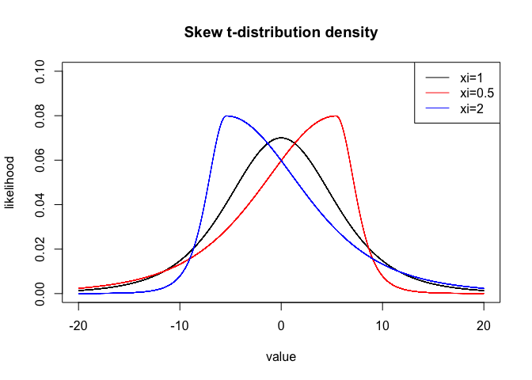

## Max vs sum plot

If the Law Of Large Numbers holds true,
$$\dfrac{\max (X_1^p, ..., X^p)}{\sum_{i=1}^n X_i^p} \rightarrow 0$$
for $n \rightarrow \infty$.

If not, $X$ doesn’t have a $p$’th moment.

See Taleb: The Statistical Consequences Of Fat Tails, p. 192